# Project Python Foundations: FoodHub Data Analysis

### Context

The number of restaurants in New York is increasing day by day. Lots of students and busy professionals rely on those restaurants due to their hectic lifestyles. Online food delivery service is a great option for them. It provides them with good food from their favorite restaurants. A food aggregator company FoodHub offers access to multiple restaurants through a single smartphone app.

The app allows the restaurants to receive a direct online order from a customer. The app assigns a delivery person from the company to pick up the order after it is confirmed by the restaurant. The delivery person then uses the map to reach the restaurant and waits for the food package. Once the food package is handed over to the delivery person, he/she confirms the pick-up in the app and travels to the customer's location to deliver the food. The delivery person confirms the drop-off in the app after delivering the food package to the customer. The customer can rate the order in the app. The food aggregator earns money by collecting a fixed margin of the delivery order from the restaurants.

### Objective

The food aggregator company has stored the data of the different orders made by the registered customers in their online portal. They want to analyze the data to get a fair idea about the demand of different restaurants which will help them in enhancing their customer experience. Suppose you are hired as a Data Scientist in this company and the Data Science team has shared some of the key questions that need to be answered. Perform the data analysis to find answers to these questions that will help the company to improve the business.

### Data Description

The data contains the different data related to a food order. The detailed data dictionary is given below.

### Data Dictionary

- order_id: Unique ID of the order
- customer_id: ID of the customer who ordered the food
- restaurant_name: Name of the restaurant
- cuisine_type: Cuisine ordered by the customer
- cost_of_the_order: Cost of the order
- day_of_the_week: Indicates whether the order is placed on a weekday or weekend (The weekday is from Monday to Friday and the weekend is Saturday and Sunday)
- rating: Rating given by the customer out of 5
- food_preparation_time: Time (in minutes) taken by the restaurant to prepare the food. This is calculated by taking the difference between the timestamps of the restaurant's order confirmation and the delivery person's pick-up confirmation.
- delivery_time: Time (in minutes) taken by the delivery person to deliver the food package. This is calculated by taking the difference between the timestamps of the delivery person's pick-up confirmation and drop-off information

### Let us start by importing the required libraries

```python
# Installing the libraries with the specified version.
#!pip install numpy==1.25.2 pandas==1.5.3 matplotlib==3.7.1 seaborn==0.13.1 -q --user
!pip install numpy==1.25.2 pandas==2.2.2 matplotlib==3.7.1 seaborn==0.13.1 -q --user
```

**Note**: *After running the above cell, kindly restart the notebook kernel and run all cells sequentially from the start again.*

```python
# import libraries for data manipulation
import numpy as np
import pandas as pd
# import libraries for data visualization
import matplotlib.pyplot as plt
import seaborn as sns
pd.set_option('display.float_format', lambda x: '%.3f' % x)
```

### Understanding the structure of the data

```python
# uncomment and run the following lines for Google Colab
from google.colab import drive
drive.mount('/content/drive')
```

```python
# Write your code here to read the data
data = pd.read_csv('/content/drive/MyDrive/Python/foodhub_order.csv')
```

```python
# Write your code here to view the first 5 rows
data.head()
```

|  | order_id | customer_id | restaurant_name | cuisine_type | cost_of_the_order | day_of_the_week | rating | food_preparation_time | delivery_time |
| --- | --- | --- | --- | --- | --- | --- | --- | --- | --- |
| 0 | 1477147 | 337525 | Hangawi | Korean | 30.750 | Weekend | Not given | 25 | 20 |
| 1 | 1477685 | 358141 | Blue Ribbon Sushi Izakaya | Japanese | 12.080 | Weekend | Not given | 25 | 23 |
| 2 | 1477070 | 66393 | Cafe Habana | Mexican | 12.230 | Weekday | 5 | 23 | 28 |
| 3 | 1477334 | 106968 | Blue Ribbon Fried Chicken | American | 29.200 | Weekend | 3 | 25 | 15 |
| 4 | 1478249 | 76942 | Dirty Bird to Go | American | 11.590 | Weekday | 4 | 25 | 24 |

### **Question 1:** How many rows and columns are present in the data? [0.5 mark]

```python
# Write your code here
print("There are", data.shape[0], 'rows and', data.shape[1], "columns.")
```

```
There are 1898 rows and 9 columns.
```

#### Observations:

- There are 1898 rows and 9 Columns in the data set
- First two rows of data in rating column shows "Not Given" as value indicating presence of data type and value other than the defined "int" (numerical)type for rating column

### **Question 2:** What are the datatypes of the different columns in the dataset? (The info() function can be used) [0.5 mark]

```python
# Write your code here
data.info()
```

```
<class 'pandas.core.frame.DataFrame'>
RangeIndex: 1898 entries, 0 to 1897
Data columns (total 9 columns):
 #   Column                 Non-Null Count  Dtype
---  ------                 --------------  -----
 0   order_id               1898 non-null   int64
 1   customer_id            1898 non-null   int64
 2   restaurant_name        1898 non-null   object
 3   cuisine_type           1898 non-null   object
 4   cost_of_the_order      1898 non-null   float64
 5   day_of_the_week        1898 non-null   object
 6   rating                 1898 non-null   object
 7   food_preparation_time  1898 non-null   int64
 8   delivery_time          1898 non-null   int64
dtypes: float64(1), int64(4), object(4)
memory usage: 133.6+ KB
```

#### Observations:

- There are 5 numerical and 4 object type columns
- We observe that all columns have entries equal to the no or rows, indicating there is no missing data
- Data type of rating column is object instead of int , as we saw some columns have values "Not Given"

### **Question 3:** Are there any missing values in the data? If yes, treat them using an appropriate method. [1 mark]

```python
# Write your code here
data.isnull().sum()
```

|  | 0 |
| --- | --- |
| order_id | 0 |
| customer_id | 0 |
| restaurant_name | 0 |
| cuisine_type | 0 |
| cost_of_the_order | 0 |
| day_of_the_week | 0 |
| rating | 0 |
| food_preparation_time | 0 |
| delivery_time | 0 |

**dtype:** int64

#### Observations:

- There is no missing data in the given data set.
- The rating value of "Not Given" should not be considered as misssing data as the cutomer chose to not provide rating for the order.
- Beofre starting EDA, we will treat this data by
  - defining 'Not given' as a seperate category ,unrated
  - treating the Not given rating as NaN and converting the data type of the rating column from object to int for Numerical Analysis
  - Imputing the Not given values will not be a recommended approach as we see below in the statistics that approximately 40%(~ie 736 orders do not have rating), impute this data as it will greatly affect the rating column.

### **Question 4:** Check the statistical summary of the data. What is the minimum, average, and maximum time it takes for food to be prepared once an order is placed? [2 marks]

```python
# Write your code here
data.describe(include='all').T
```

|  | count | unique | top | freq | mean | std | min | 25% | 50% | 75% | max |
| --- | --- | --- | --- | --- | --- | --- | --- | --- | --- | --- | --- |
| order_id | 1898.000 | NaN | NaN | NaN | 1477495.500 | 548.050 | 1476547.000 | 1477021.250 | 1477495.500 | 1477969.750 | 1478444.000 |
| customer_id | 1898.000 | NaN | NaN | NaN | 171168.478 | 113698.140 | 1311.000 | 77787.750 | 128600.000 | 270525.000 | 405334.000 |
| restaurant_name | 1898 | 178 | Shake Shack | 219 | NaN | NaN | NaN | NaN | NaN | NaN | NaN |
| cuisine_type | 1898 | 14 | American | 584 | NaN | NaN | NaN | NaN | NaN | NaN | NaN |
| cost_of_the_order | 1898.000 | NaN | NaN | NaN | 16.499 | 7.484 | 4.470 | 12.080 | 14.140 | 22.297 | 35.410 |
| day_of_the_week | 1898 | 2 | Weekend | 1351 | NaN | NaN | NaN | NaN | NaN | NaN | NaN |
| rating | 1898 | 4 | Not given | 736 | NaN | NaN | NaN | NaN | NaN | NaN | NaN |
| food_preparation_time | 1898.000 | NaN | NaN | NaN | 27.372 | 4.632 | 20.000 | 23.000 | 27.000 | 31.000 | 35.000 |
| delivery_time | 1898.000 | NaN | NaN | NaN | 24.162 | 4.973 | 15.000 | 20.000 | 25.000 | 28.000 | 33.000 |

#### Observations:

Answers

  **Observations** from Statistical Summary
  - restaurant_name -There are 178 restuarants and | -Shake Shack is the most popular one with 219 orders
  - cuisine_type : -There are 14 unique cuisine type, -American is the most popular cuisine having 584 orders
  - cost_of_the_order -Avg orders cost is 16.5 dollars -min order cost is 4.5 and Max order cost is 35 $
  - day_of_the_week -weekends have higher order frequency than weekdays
  - rating -There are 736 orders for which rating is 'Not given'
  - delivery_time -Average Delivery time is 24 mins , min is 15 mins and max delivery time is 33 mins

### **Question 5:** How many orders are not rated? [1 mark]

```python
# This can be inferred from Stats above as well as derived via code
# No of Not rated Orders
not_rated=data['rating'].value_counts()['Not given']
print('There are', not_rated ,'numbers of orders which are not rated.')
```

```
There are 736 numbers of orders which are not rated.
```

#### Observations:

- 736 rows(~40% ) of the total orders not rated
- Remaining (~60%) ie 1162 orders are rated

### Exploratory Data Analysis (EDA)

- Befor starting EDA, we will treat the 'rating'coloumn as mentioned in observation Q3

```python
# Create a new category 'unrated' with all values as 'Not given' in the rating column
data['unrated'] = data['rating'].apply(lambda x: 'Not given' if x == 'Not given' else None)

#In the rating column replace all Not Given values with Nan
data['rating'] = data['rating'].replace('Not given', np.nan)

#Set the data type of rating column as Int
data['rating'] = data['rating'].astype(float).astype('Int64')

#check data info for the treated colum to valudate the Rating data type and newly added unrated colum
data.info()
```

```
<class 'pandas.core.frame.DataFrame'>
RangeIndex: 1898 entries, 0 to 1897
Data columns (total 10 columns):
 #   Column                 Non-Null Count  Dtype
---  ------                 --------------  -----
 0   order_id               1898 non-null   int64
 1   customer_id            1898 non-null   int64
 2   restaurant_name        1898 non-null   object
 3   cuisine_type           1898 non-null   object
 4   cost_of_the_order      1898 non-null   float64
 5   day_of_the_week        1898 non-null   object
 6   rating                 1162 non-null   Int64
 7   food_preparation_time  1898 non-null   int64
 8   delivery_time          1898 non-null   int64
 9   unrated                736 non-null    object
dtypes: Int64(1), float64(1), int64(4), object(4)
memory usage: 150.3+ KB
```

```python
data.describe(include='all').T
```

|  | count | unique | top | freq | mean | std | min | 25% | 50% | 75% | max |
| --- | --- | --- | --- | --- | --- | --- | --- | --- | --- | --- | --- |
| order_id | 1898.000 | NaN | NaN | NaN | 1477495.500 | 548.050 | 1476547.000 | 1477021.250 | 1477495.500 | 1477969.750 | 1478444.000 |
| customer_id | 1898.000 | NaN | NaN | NaN | 171168.478 | 113698.140 | 1311.000 | 77787.750 | 128600.000 | 270525.000 | 405334.000 |
| restaurant_name | 1898 | 178 | Shake Shack | 219 | NaN | NaN | NaN | NaN | NaN | NaN | NaN |
| cuisine_type | 1898 | 14 | American | 584 | NaN | NaN | NaN | NaN | NaN | NaN | NaN |
| cost_of_the_order | 1898.000 | NaN | NaN | NaN | 16.499 | 7.484 | 4.470 | 12.080 | 14.140 | 22.297 | 35.410 |
| day_of_the_week | 1898 | 2 | Weekend | 1351 | NaN | NaN | NaN | NaN | NaN | NaN | NaN |
| rating | 1162.000 | <NA> | <NA> | <NA> | 4.344 | 0.741 | 3.000 | 4.000 | 5.000 | 5.000 | 5.000 |
| food_preparation_time | 1898.000 | NaN | NaN | NaN | 27.372 | 4.632 | 20.000 | 23.000 | 27.000 | 31.000 | 35.000 |
| delivery_time | 1898.000 | NaN | NaN | NaN | 24.162 | 4.973 | 15.000 | 20.000 | 25.000 | 28.000 | 33.000 |
| unrated | 736 | 1 | Not given | 736 | NaN | NaN | NaN | NaN | NaN | NaN | NaN |

**Let's check the count and percentage of categorical levels in each column**

```python
# Printing the count of unique categorical levels in each column
cat_cols =['cuisine_type','restaurant_name', 'day_of_the_week','unrated']
for column in cat_cols:
    print(data[column].value_counts())
    print("-" * 50)
```

```
cuisine_type
American          584
Japanese          470
Italian           298
Chinese           215
Mexican            77
Indian             73
Middle Eastern     49
Mediterranean      46
Thai               19
French             18
Southern           17
Korean             13
Spanish            12
Vietnamese          7
Name: count, dtype: int64
--------------------------------------------------
restaurant_name
Shake Shack                  219
The Meatball Shop            132
Blue Ribbon Sushi            119
Blue Ribbon Fried Chicken     96
Parm                          68
                            ...
Sushi Choshi                   1
Dos Caminos Soho               1
La Follia                      1
Philippe Chow                  1
'wichcraft                     1
Name: count, Length: 178, dtype: int64
--------------------------------------------------
day_of_the_week
Weekend    1351
Weekday     547
Name: count, dtype: int64
--------------------------------------------------
unrated
Not given    736
Name: count, dtype: int64
--------------------------------------------------
```

```python
# Printing the percentage of unique categorical levels in each column
for column in cat_cols:
    print(data[column].value_counts(normalize=True))
    print("-" * 50)
```

```
cuisine_type
American         0.308
Japanese         0.248
Italian          0.157
Chinese          0.113
Mexican          0.041
Indian           0.038
Middle Eastern   0.026
Mediterranean    0.024
Thai             0.010
French           0.009
Southern         0.009
Korean           0.007
Spanish          0.006
Vietnamese       0.004
Name: proportion, dtype: float64
--------------------------------------------------
restaurant_name
Shake Shack                 0.115
The Meatball Shop           0.070
Blue Ribbon Sushi           0.063
Blue Ribbon Fried Chicken   0.051
Parm                        0.036
                             ...
Sushi Choshi                0.001
Dos Caminos Soho            0.001
La Follia                   0.001
Philippe Chow               0.001
'wichcraft                  0.001
Name: proportion, Length: 178, dtype: float64
--------------------------------------------------
day_of_the_week
Weekend   0.712
Weekday   0.288
Name: proportion, dtype: float64
--------------------------------------------------
unrated
Not given   1.000
Name: proportion, dtype: float64
--------------------------------------------------
```

**Observations**

- Hisgest No of orders are of American cusine(584), follweded by Japanese(470)
- Ameriacn/Japanese/Italian/Chinese consitute of 80% of the orders hence our analysis will be baised towards these cuisines
- 72% of the orders are placed during weekends so our analysis should look into
  - what is supporting more orders to be efficiently delivered on weekends
  - any factors affecting orders on weekdays

### **Question 6:** Explore all the variables and provide observations on their distributions. (Generally, histograms, boxplots, countplots, etc. are used for univariate exploration.) [9 marks]

### **Checking Numerical Columns**

**Observations : Order Cost**

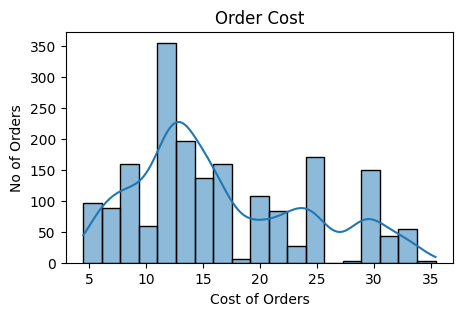

```python
#a.Observation on Price
plt.figure(figsize=(5,3))
plt.title('Order Cost')
plt.xlabel('Cost of Orders')
plt.ylabel('No of Orders')
sns.histplot(data=data, x='cost_of_the_order', kde=True)
plt.show()
```

**Observation**

- Distribution is slightly right skewed indicating there are more orders(data points) which are priced less than mean price of 16.5$

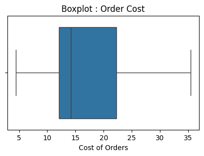

```python
plt.figure(figsize=(5,3))
sns.boxplot(data=data,x='cost_of_the_order')
plt.title('Boxplot : Order Cost')
plt.xlabel('Cost of Orders')
```

**Observation**

- There are no outliers and cost
- 75% of the orders lie below 23$

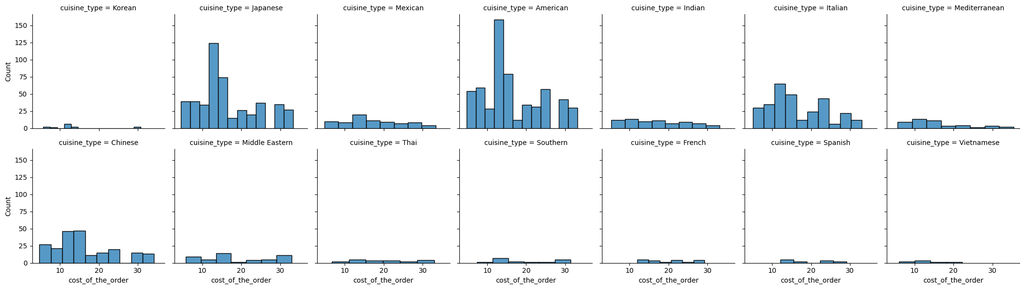

```python
#b.Observation on order count and price by cuisine type
g=sns.FacetGrid(data, col="cuisine_type", col_wrap=7)
g.map(sns.histplot,"cost_of_the_order")
```

### Observation

- Most popular cuisine is american, followed by Japanese, Italian,chinese in sequence
- Vietnamese,Korean, Thai, Southern, French,Southern,French, Spanish are less popular.This will be agood point to analysze on the baisis of ratings and delivery time to extablish the co relation

**Observation : Food Preparation Time**

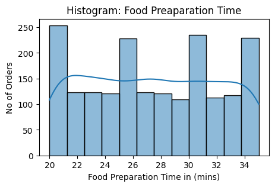

```python
plt.figure(figsize=(5,3))
plt.title('Histogram: Food Preaparation Time')
plt.xlabel('Food Preparation Time in (mins)')
plt.ylabel('No of Orders')
sns.histplot(data=data, x='food_preparation_time', kde=True)
```

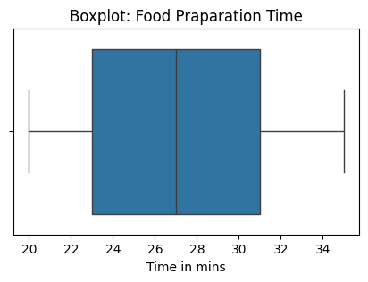

```python
plt.figure(figsize=(5,3))
sns.boxplot(data=data,x='food_preparation_time')
plt.title('Boxplot: Food Praparation Time')
plt.xlabel('Time in mins')
```

**Observations : delivery time**

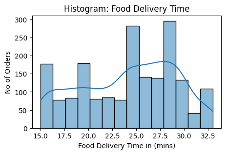

```python
plt.figure(figsize=(5,3))
plt.title('Histogram: Food Delivery Time')
plt.xlabel('Food Delivery Time in (mins)')
plt.ylabel('No of Orders')
sns.histplot(data=data, x='delivery_time', kde=True)
```

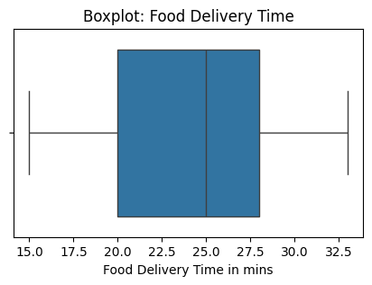

```python
plt.figure(figsize=(5,3))
sns.boxplot(data=data,x='delivery_time')
plt.title('Boxplot: Food Delivery Time')
plt.xlabel('Food Delivery Time in mins')
```

**Observations** The distribution is slighty left skewed, which means more orders have been delivered after mean time of 24 mins There are no outliers in the delivery time

**Observation : Rating**

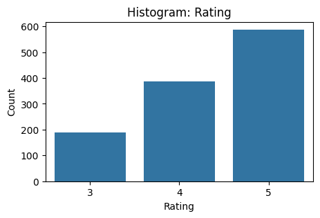

```python
plt.figure(figsize=(5,3))
plt.title('Histogram: Rating')
plt.xlabel('Rating')
plt.ylabel('Count')
sns.countplot(data=data, x='rating')
```

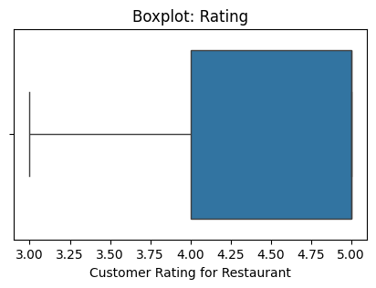

```python
plt.figure(figsize=(5,3))
sns.boxplot(data=data,x='rating')
plt.title('Boxplot: Rating')
plt.xlabel('Customer Rating for Restaurant')
```

**Observations**

Most Rated orders have the rating of 5. Some orders are rated 3, 50% of the orders are rated 5

**Observations : Categorical Variables**

Observation : Weekday/Weekend Delivery

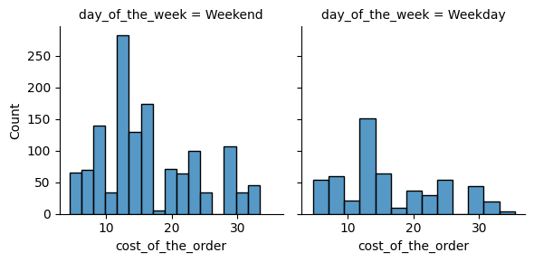

```python
#c.Order counts in weekdays and weekends
plt.figure(figsize=(5,3))
g=sns.FacetGrid(data, col="day_of_the_week")
g.map(sns.histplot,"cost_of_the_order")
```

**Observation**

- Frequency of orders is considerably more on Weekends than Weekdays

**Obervation : Cuisine Type**

```
WARNING:matplotlib.legend:No artists with labels found to put in legend.  Note that artists whose label start with an underscore are ignored when legend() is called with no argument.
```

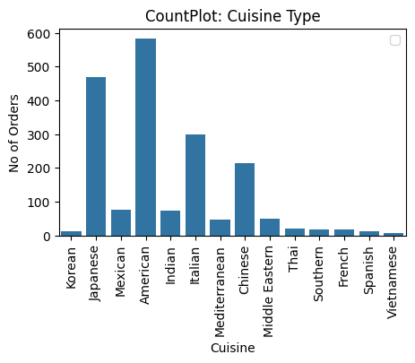

```python
#b.Observation on order count and price by cuisine type
plt.figure(figsize=(5,3))
plt.title('CountPlot: Cuisine Type')
plt.xlabel('Cuisine')
plt.ylabel('No of Orders')
sns.countplot(data=data, x='cuisine_type');
plt.xticks(rotation=90)
plt.legend(loc='upper right')
```

```
WARNING:matplotlib.legend:No artists with labels found to put in legend.  Note that artists whose label start with an underscore are ignored when legend() is called with no argument.
```

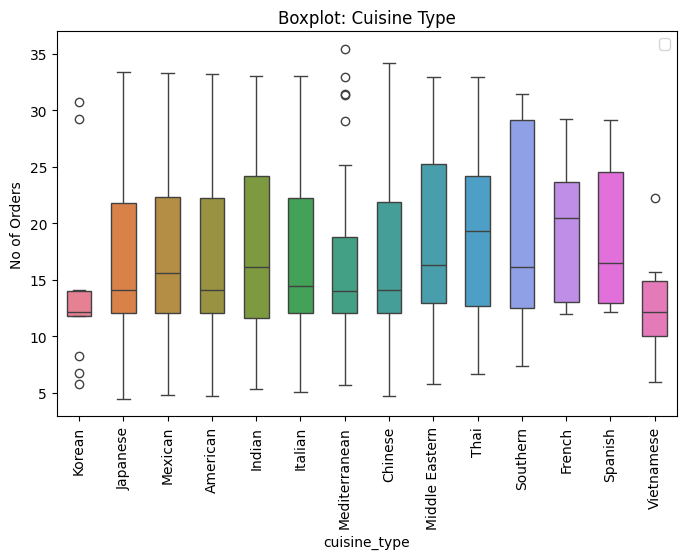

```python
plt.figure(figsize=(8,5))
plt.title('Boxplot: Cuisine Type')
plt.xlabel('Cuisine')
plt.ylabel('No of Orders')
sns.boxplot(data=data, y='cost_of_the_order',x='cuisine_type', gap=.3,hue='cuisine_type' );
plt.xlabel('cuisine_type')
plt.xticks(rotation=90)
plt.legend(loc='upper right')
```

**Observations on Cuisine Type**

- American/Japanese/Italian/Chinese are the most popuar cuisines
- There are some outliers in korean, Vietnamese and Mediterranean cuisines

**Observations : Restuarant Name Category**

Since there are 178 unique retuarants , we will analyse by restaurants with top 10 orders

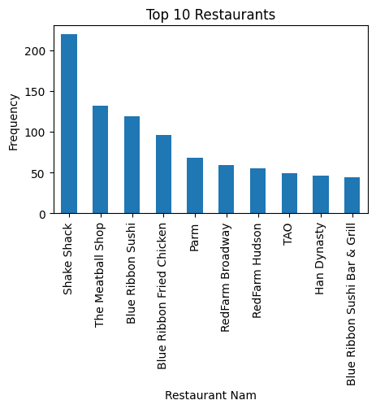

```python
#Plot Bar chart with top 10 frequency orders
plt.figure(figsize=(5,3))
frequency = data['restaurant_name'].value_counts()
top_10 = frequency.head(10)
top_10.plot(kind='bar')
plt.xlabel('Restaurant Nam')
plt.ylabel('Frequency')
plt.title('Top 10 Restaurants')
plt.xticks(rotation=90)
plt.show()
```

**Observations on Restaurant names** The Top 10 restuarants are can be seen above with their actual and percentage distribution.

### **Question 7**: Which are the top 5 restaurants in terms of the number of orders received? [1 mark]

```python
#Count the no of orders per restuarant
order_counts = data.groupby('restaurant_name').size().reset_index(name='order_count')

# Sort and select the top 5 restaurants
top_5_restaurants = order_counts.sort_values(by='order_count', ascending=False).head(5)
print(top_5_restaurants)
```

```
               restaurant_name  order_count
136                Shake Shack          219
153          The Meatball Shop          132
21           Blue Ribbon Sushi          119
20   Blue Ribbon Fried Chicken           96
109                       Parm           68
```

#### Observations:

1. The top 5 Restuarants having max no of orders are

   restaurant_name order_count Shake Shack 219 The Meatball Shop 132 Blue Ribbon Sushi 119 Blue Ribbon Fried Chicken 96 Parm 68
2. No of orders per restuarant range from 1 to 219, showing a great variance.
3. Every restuarant received atleast one order

### **Question 8**: Which is the most popular cuisine on weekends? [1 mark]

```python
# Write the code here
weekends = ['Weekend']
weekend_data = data[data['day_of_the_week'].isin(weekends)]

cuisine_counts = weekend_data.groupby('cuisine_type').size().reset_index(name='order_count')

most_popular_cuisine = cuisine_counts.sort_values(by='order_count', ascending=False).iloc[0]
print("Most popular cuisine on weekends:")
print(most_popular_cuisine)
```

```
Most popular cuisine on weekends:
cuisine_type    American
order_count          415
Name: 0, dtype: object
```

#### Observations:

American Cuisine is most popular on the weekend with the highest numbers of orders placed

### **Question 9**: What percentage of the orders cost more than 20 dollars? [2 marks]

```python
#Count of orders above 20 $ cost
orders_above_20=data[data['cost_of_the_order'] > 20].shape[0]

#Percentage of orders above 20$ cost
percentage_orders_above_20 = (orders_above_20/data.shape[0])*100
print(round(percentage_orders_above_20,2),"% of the total orders cost more than 20$")
```

```
29.24 % of the total orders cost more than 20$
```

#### Observations:

- 29% of the orders cost more than 20$

### **Question 10**: What is the mean order delivery time? [1 mark]

```python
# Write the code here
print("The mean order delivery time is",round(data['delivery_time'].mean(),2),"minutes")
```

```
The mean order delivery time is 24.16 minutes
```

#### Observations:

The mean order delivery time is 24.16 minutes

### **Question 11:** The company has decided to give 20% discount vouchers to the top 3 most frequent customers. Find the IDs of these customers and the number of orders they placed. [1 mark]

```python
# Write the code here
customer_freq = data['customer_id'].value_counts()
top_3 = customer_freq.head(3)
print(top_3 )
```

```
customer_id
52832    13
47440    10
83287     9
Name: count, dtype: int64
```

#### Observations:

The top three customers are

- [ Customer Id 52832 Order 13]
- [ Customer Id 47440 Order 10]
- [ Customer Id 83287 Order 9]

### **Question 12**: Perform a multivariate analysis to explore relationships between the important variables in the dataset. (It is a good idea to explore relations between numerical variables as well as relations between numerical and categorical variables) [10 marks]

**Multi Variate Analysis**

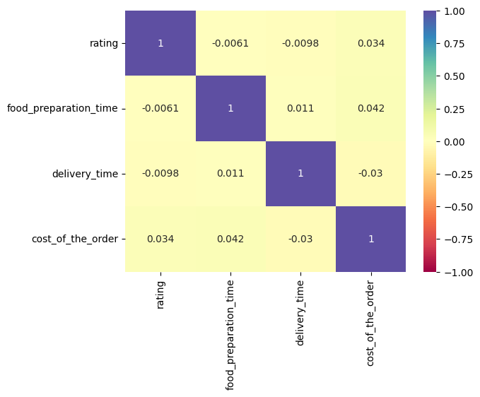

```python
plt.figure(figsize=(5,3))
plt.show()
sns.heatmap(data=data[['rating','food_preparation_time','delivery_time','cost_of_the_order']].corr(), annot=True, cmap='Spectral',vmin=-1,vmax=1);
```

**Observations** None of the numerical are showing strong co-relations to draw any inferences

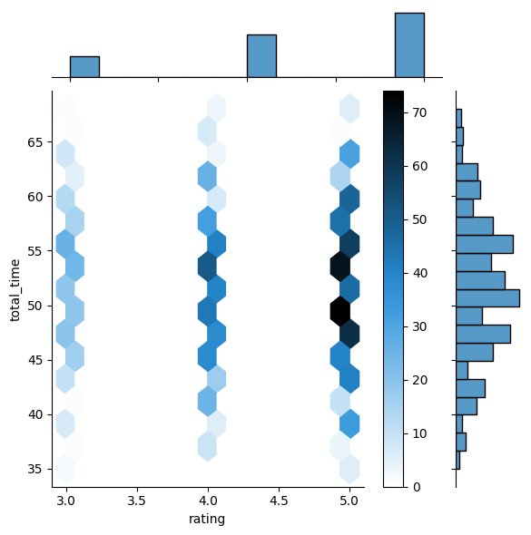

```python
#Data to explore relationship between rating and total time taken from the order placed to delivery received
plt.figure(figsize=(5,3))
data['total_time']=data['food_preparation_time']+ data['delivery_time']
sns.jointplot(data=data, y='total_time', x='rating', kind="hex");
plt.colorbar();
```

**Observation**

Density of highest rated orders are highest when total time taken between 47 to 57 mins which can be interpreted as less than an hour

**Relationship between Numeric variables**

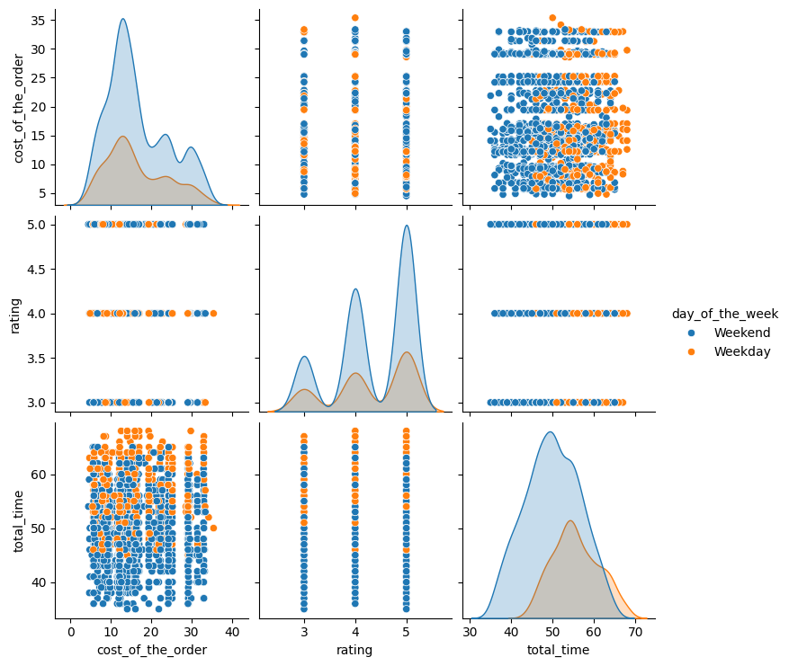

```python
plt.figure(figsize=(5,3))
sns.pairplot(data=data, vars=['cost_of_the_order','rating','total_time'], hue='day_of_the_week');
```

**Observations**

**Relationship : Cuisine and Rating**

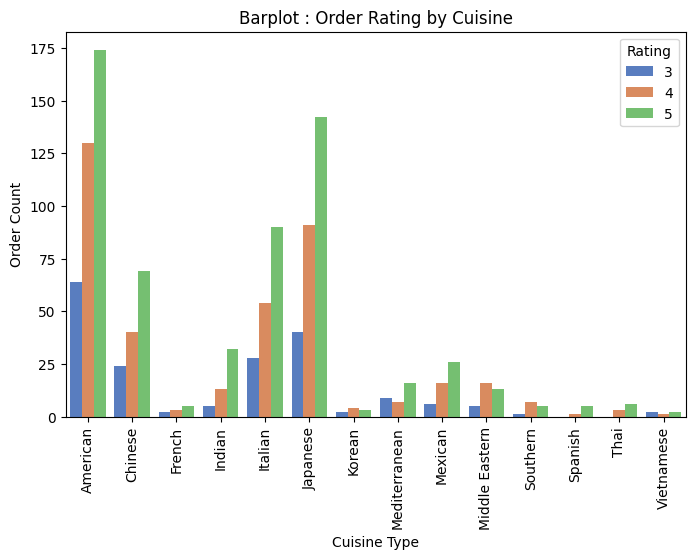

```python
#Group by cuisine type and rating
grouped_data = data.groupby(['cuisine_type', 'rating']).size().reset_index(name='grouped_order_count')
plt.figure(figsize=(8, 5))
sns.barplot(x='cuisine_type', y='grouped_order_count', hue='rating', data=grouped_data, palette='muted')
plt.title('Barplot : Order Rating by Cuisine')
plt.xlabel('Cuisine Type')
plt.ylabel('Order Count')
plt.legend(title='Rating')
plt.xticks(rotation=90)
plt.show()
```

**Observation** American cuisine has highest ratings followed by Japanese (which should be considered while giving promotion offers)

*Relation : Restuarants & Rating*

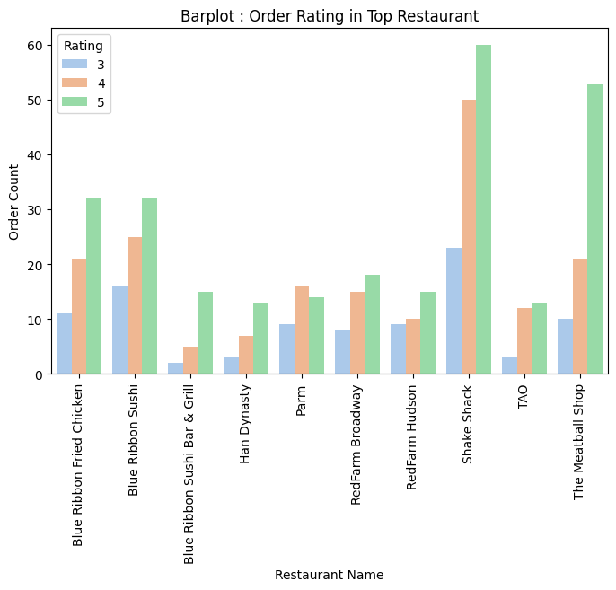

```python
top_10_restaurants = top_10.index.tolist()
data_top_10 = data[data['restaurant_name'].isin(top_10_restaurants)]
grouped_data = data_top_10.groupby(['restaurant_name', 'cuisine_type']).size().reset_index(name='order_count')
grouped_data_rating = data_top_10.groupby(['restaurant_name', 'rating']).size().reset_index(name='order_count')
# Create a bar plot to visualize the order count by restaurant and rating type
plt.figure(figsize=(8, 5))
sns.barplot(x='restaurant_name', y='order_count', hue='rating', data=grouped_data_rating, palette='pastel')
plt.title('Barplot : Order Rating in Top Restaurant')
plt.xlabel('Restaurant Name')
plt.ylabel('Order Count')
plt.legend(title='Rating')
plt.xticks(rotation=90)
plt.show()
```

**Observations** Shake Shack is the Best Rated restuarant followed by The Meatball Shop

*Relation ship: Restaurant and cuisine*

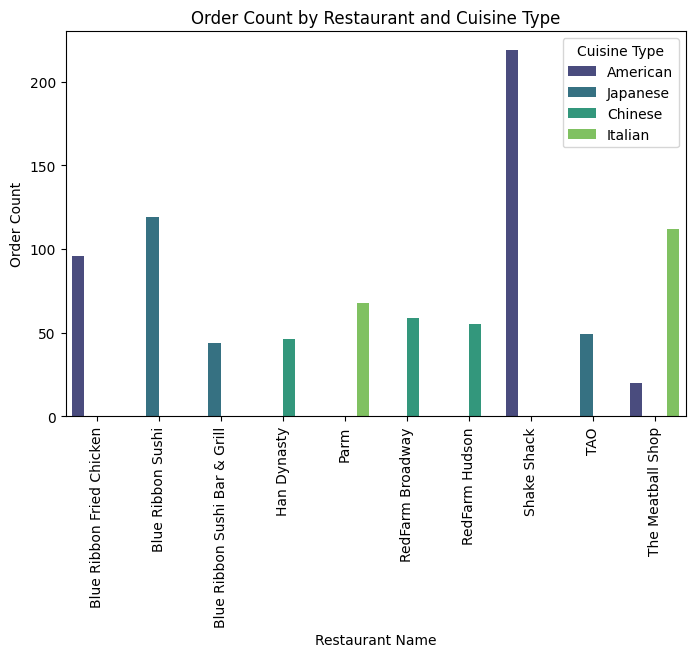

```python
data_top_10 = data[data['restaurant_name'].isin(top_10_restaurants)]
grouped_data = data_top_10.groupby(['restaurant_name', 'cuisine_type']).size().reset_index(name='order_count')
# Create a bar plot to visualize the order count by restaurant and cuisine type
plt.figure(figsize=(8, 5))
sns.barplot(x='restaurant_name', y='order_count', hue='cuisine_type', data=grouped_data, palette='viridis')
plt.title('Order Count by Restaurant and Cuisine Type')
plt.xlabel('Restaurant Name')
plt.ylabel('Order Count')
plt.legend(title='Cuisine Type')
plt.xticks(rotation=90)
plt.show()
```

**Observatios** Most Popular Restuarants by Cuisine

- American cuisine :

  ```
             Shake Shack(219),
              Blue Ribbon Fried Chicken(96)
              Meatball Shop(20)
  ```

- Japanese Cuisine :

  ```
              Blue Ribbon Sushi(119)
               Blue Ribbon Sushi Bar & Grill(44)
               TAO (49)
  ```

- Italian Cuisine

  ```
            The Meatball Shop (112)
            Parm(68)
  ```

- Chinese Cuisine

  ```
        Han Dynasty (46)
        RedFarm Broadway (59)
        RedFarm Hudson(55)
  ```

### **Question 13:** The company wants to provide a promotional offer in the advertisement of the restaurants. The condition to get the offer is that the restaurants must have a rating count of more than 50 and the average rating should be greater than 4. Find the restaurants fulfilling the criteria to get the promotional offer. [3 marks]

#### Observations:

**Observations** This can be solved by analysing the graphs without writing code

- From Restaurants By Cuisine BarPlot,
- Filter Restarants having more than 50 orders

[output not shown]

### **Question 14:** The company charges the restaurant 25% on the orders having cost greater than 20 dollars and 15% on the orders having cost greater than 5 dollars. Find the net revenue generated by the company across all orders. [3 marks]

```python
# #Define a function that will take cost of order as parameter and conditiobally evaluate the charge on the order price
def charge(cost_of_the_order):
  if cost_of_the_order > 20:
    return 0.25 * cost_of_the_order
  elif   cost_of_the_order > 5:
   return 0.15 * cost_of_the_order

#Add a new column called charge where data in each row  will be filled by applying the function written above with cost of that order
data['charge']=data['cost_of_the_order'].apply(charge)

#Total Revenue of the company will be the summation of all charges
total_revenue=data['charge'].sum()
print("The total revenue of the company is $", total_revenue)
```

```
The total revenue of the company is $ 6166.303
```

#### Observations:

### **Question 15:** The company wants to analyze the total time required to deliver the food. What percentage of orders take more than 60 minutes to get delivered from the time the order is placed? (The food has to be prepared and then delivered.) [2 marks]

```python
#Determine total time for every order and add a new column in the dataframe with total-time value
data['total_time']=data['food_preparation_time']+ data['delivery_time']

#Count the number of orders whose total time is over 60 mins
orders_above_60= data[data['total_time']>60].shape[0]

#Calculate the percentage of orders which took over 60 mins in total
percentage_over_60 = (orders_above_60 / data.shape[0])*100
print(round(percentage_over_60, 2),"% of the total orders take more than 60 minutes to get deliverded after the order is placed")
```

```
10.54 % of the total orders take more than 60 minutes to get deliverded after the order is placed
```

#### Observations:

### **Question 16:** The company wants to analyze the delivery time of the orders on weekdays and weekends. How does the mean delivery time vary during weekdays and weekends? [2 marks]

```python
#Calculat ethe mean delivery time for weekdays and weekends
avg_delivery_time = data.groupby('day_of_the_week')['delivery_time'].mean()
print(avg_delivery_time)
```

```
day_of_the_week
Weekday   28.340
Weekend   22.470
Name: delivery_time, dtype: float64
```

#### Observations:

- Average Delivery time durig Weekdays is more than Average delivery time during weekends.

### Conclusion and Recommendations

### **Question 17:** What are your conclusions from the analysis? What recommendations would you like to share to help improve the business? (You can use cuisine type and feedback ratings to drive your business recommendations.) [6 marks]

### Conclusions:

- 1. Customers in NewYork ordered from 178 unique restuarants via Food Hub Delivery Service
- 1. Customers ordered 14 unique types of Cusines
- 1. Average order cost is 16.5 $ and there are more orders of less that Average cost
- 1. Weekends are busier than weekdays
- 1. Total Time from order placement to order delivery is higher on weekdays than weekends
- 1. Maximum highest rated orders are total time is less than 60 mins
- 1. American Cuisine ordered the most popular and highest reated followed by Japanese,Italian and Chinese
- 1. Restuarants serving American cusisines are rated the higes
- 1. Approximately 60 % customers rated the orders, average rating more than 4
- 1. Approximately 40% customers did not provide rating on the delivery App

### Recommendations:

- 1. American And Japanese cuisine types are the most polular -Food Hub should offer discount/offers to drive more orders for these cuisine types -Food Hub should add more restaurants of these cusine types in their delivery network
- 1. Run weekend promotionsal for Most Popular Restuarants with higher ratings as orders density is higher on weekends
- 1. Incentivise customer using the app to provide feedback rating, in order to drive better business decisions
- 1. Work on reducing delivery time on weekdays